# Assessment of Mental Health Need Before, During, and After COVID-19

Jensen Hu

## Purpose

The purpose of this assessment is to identify areas of potentially increased mental health need as a result of COVID-19 in NYC. The resulting aim is to route public health efforts and mental health resources to those identified areas of highest need.

## Background of Datasets

**For this assessment, we will use the CDC’s Social Vulnerability Index along with the child opportunity index to establish the baseline mental health need in NYC. COVID19 related data will then be added onto this baseline as a “COVID19 Layer” to identify those areas of increased mental health need in the context of COVID19**

#### **Social Vulnerability Index (SVI)**

- **Background**: In the context of the global COVID-19 pandemic, “SVI data can be used to identify communities that will need continued support to recover following an emergency or natural disaster, and allocate emergency preparedness funding by community need.” As seen in current events, COVID19 disproportionately affects Black and Hispanic communities. It is evident that public health institutions not only factor in, but lead with the social determinants of health – which contribute to racial inequities in health– when planning and executing emergency resource allocation during and after COVID19.

#### **Exploration of Social Vulnerability Index (SVI)**

SVI consists of 15 census variables organized into 4 different themes:

- Socioeconomic Status (**RPL_THEME1**),
- Household Composition & Disability (**RPL_THEME2**),
- Minority Status & Language (**RPL_THEME3**),
- Housing & Transportation (**RPL_THEME4**) and,
- In Summary, an overall Social Vulnerabilities Index (**RPL_THEMES**).

These themes are measured in percentile rank. A higher percentile rank represents greater vulnerability, with a percentile rank of 0.00 meaning the least vulnerable and 1.00 meaning the most vulnerable. Reference:https://svi.cdc.gov/Documents/Data/2016_SVI_Data/SVI2016Documentation.pdf

These rankings have been alloted by census tract (GEOID)– “uniquely numbered subdivisions of a county, representing a neighborhood averaging about 4,000 inhabitants.” NYC has 5 different counties (“New York”, “Kings”, “Bronx”, “Richmond”, “Queens”) which have been subdivided into 2,166 census tracts. To provide a frame of reference, census tracts are more granular than zip codes. There are 178 zip codes in NYC.

To begin, we will review SVI data by NYC county.

##### **Review of SVI Data by NYC County**

| COUNTY | FIPS | LOCATION | RPL_THEME1 | RPL_THEME2 | RPL_THEME3 | RPL_THEME4 | RPL_THEMES |
| --- | --- | --- | --- | --- | --- | --- | --- |
| Richmond | 36085 | Richmond County, New York | 0.2951 | 0.1967 | 0.8852 | 0.7049 | 0.5410 |
| New York | 36061 | New York County, New York | 0.5738 | 0.0164 | 0.9508 | 0.9672 | 0.6393 |
| Queens | 36081 | Queens County, New York | 0.7049 | 0.0328 | 0.9836 | 0.7213 | 0.7377 |
| Kings | 36047 | Kings County, New York | 0.9016 | 0.3770 | 0.9672 | 0.8525 | 0.9180 |
| Bronx | 36005 | Bronx County, New York | 1.0000 | 0.8033 | 1.0000 | 0.9508 | 1.0000 |

##### **Mapping SVI data by County**

[interactive chart not shown]

At a glance, the Bronx county has the highest overall social vulnerability (RPL_THEMES=1.000) followed by Kings county (RPL_THEMES=0.918) within the counties in NYC. This seems to indicate that these two counties are likely to be substantially impacted by COVID19 and would need priority allocation of emergency resources. Arguably, the ranking of least to most socially vulnerable aligns with mental health need within the counties.

Now, let’s take a look at how COVID19 has impacted NYC counties to date:

| COUNTY | BOROUGH_GROUP | COVID_CASE_COUNT | COVID_CASE_RATE |
| --- | --- | --- | --- |
| Bronx | The Bronx | 36969 | 2512.67 |
| Kings | Brooklyn | 42996 | 1585.01 |
| New York | Manhattan | 20121 | 1069.07 |
| Queens | Queens | 50304 | 2010.93 |
| Richmond | Staten Island | 11752 | 2338.97 |
| NA | Citywide | 162212 | NA |

The above contains cumulative, age adjusted rates of confirmed cases per 100,000 people, by NYC borough of residence. We can see that The Bronx (Bronx County) and Staten Island (Richmond County) have higher COVID case rates in relation to all other counties. Assuming COVID case rate is an indicator of “COVID impact”, let’s incorporate this data into the current SVI rankings.

Note: I don’t think it’s this easy.

##### **Adding COVID DATA into Percent Ranking in SVI**

| COUNTY | BOROUGH_GROUP | SPL_THEMES | COVID_CASE_RATE | covid_rank | adj_SPL | svi_covid_rank |
| --- | --- | --- | --- | --- | --- | --- |
| Richmond | Staten Island | 7.4917 | 2338.97 | 0.75 | 8.2417 | 0.25 |
| New York | Manhattan | 7.8524 | 1069.07 | 0.00 | 7.8524 | 0.00 |
| Queens | Queens | 8.1966 | 2010.93 | 0.50 | 8.6966 | 0.50 |
| Kings | Brooklyn | 9.9672 | 1585.01 | 0.25 | 10.2172 | 0.75 |
| Bronx | The Bronx | 11.8525 | 2512.67 | 1.00 | 12.8525 | 1.00 |

- To do this, the case rate was percent ranked by county then added that to the SVI’s raw score – SPL_THEMES and then a second percent rank on that “adjusted SPL THEMES” was performed to give a COVID SVI percent rank.

Based on the new “svi_covid_rank”, we can see that Bronx and Kings county still hold their rank as the highest in social vulnerability in the context of COVID.

##### **Mapping COVID adjusted SVI data by County**

[interactive chart not shown]

##### Review of SVI by Census Tract

As mentioned above, each county is subdivided by census tracts. Number of census tracts by county:

| COUNTY | Census_Tracts |
| --- | --- |
| Kings | 761 |
| Queens | 669 |
| Bronx | 339 |
| New York | 288 |
| Richmond | 109 |

##### Scatter plot of Overall Percentile ranks of each Census Tract by County

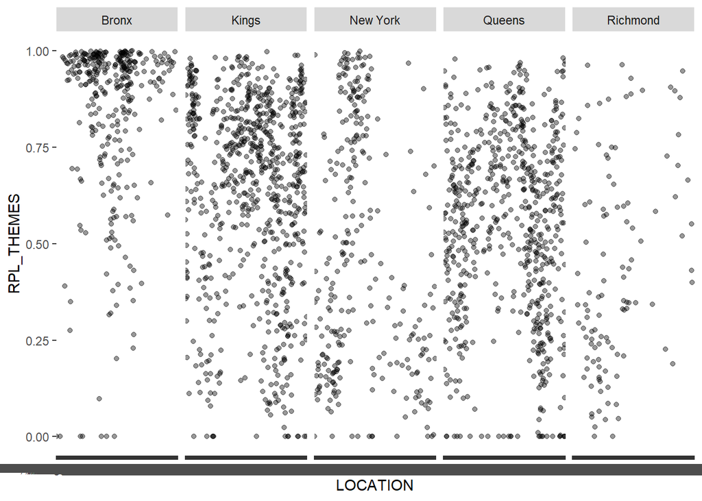

##### Overall SVI Rank to Quantile Categories

The overall ranked vulnerability is measured from 0 to 1. In order to provide a bit more practical use out of this measure, we’ll categorize by quantiles.

```
##      0%     25%     50%     75%    100%
## 0.00000 0.39635 0.65910 0.84460 1.00000
```

Values from 0.84460 to 1 will be considered as “Highest Vulnerability” Values from 0.65910 to 0.84460 will be considered as “High Medium Vulnerability” Values from 0.39635 to 0.65910 will be considered as “Low Middle Vulnerability” Values from 0.000 to 0.39635 will be considered as “Lowest Vulnerability”

##### Number of Census Tracts ranked by Social Vulnerability Cat by County

| COUNTY | Lowest Vulnerability | Low Medium Vulnerability | High Medium Vulnerability | Highest Vulnerability |
| --- | --- | --- | --- | --- |
| Bronx | 21 | 36 | 48 | 234 |
| Kings | 144 | 192 | 256 | 169 |
| New York | 141 | 43 | 47 | 57 |
| Queens | 179 | 244 | 176 | 70 |
| Richmond | 57 | 26 | 13 | 13 |

##### Scatter plot of Overall Percentile ranks of each Census Tract by County & Social Vulnerability Cat

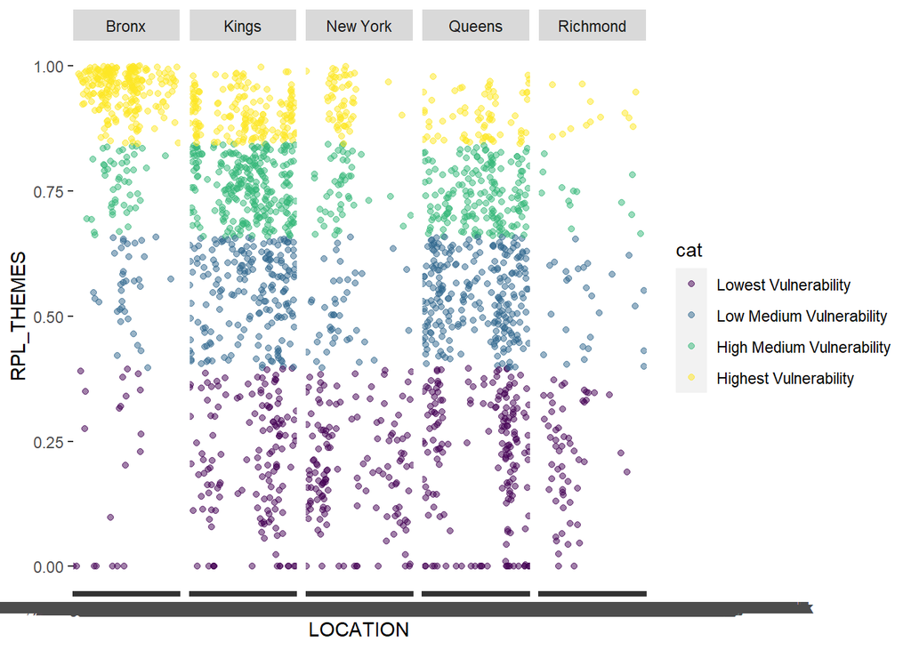

#### ZIP CODE CLEAN/TRANSFORM #178 zip codes in nyc

#### Child Opportunity Index (COI)

### Interactive Leaflet - COVID19 % Positive by Zip & SVI and COI by Census Tract

[interactive chart not shown]